# Machine Learning Project

Jeff Young

3 March 2017

# Background

Using devices such as Jawbone Up, Nike FuelBand, and Fitbit it is now possible to collect a large amount of data about personal activity relatively inexpensively. These type of devices are part of the quantified self movement – a group of enthusiasts who take measurements about themselves regularly to improve their health, to find patterns in their behavior, or because they are tech geeks. One thing that people regularly do is quantify how much of a particular activity they do, but they rarely quantify how well they do it. In this project, your goal will be to use data from accelerometers on the belt, forearm, arm, and dumbell of 6 participants. They were asked to perform barbell lifts correctly and incorrectly in 5 different ways. More information is available from the website here: http://groupware.les.inf.puc-rio.br/har (see the section on the Weight Lifting Exercise Dataset).

```r
#load the data from the files placing NA for all non-values

testing_data_raw <- read.csv('pml-testing.csv', header = TRUE, na.strings = c("NA","NaN","","#DIV/0!"))
training_data_raw <- read.csv('pml-training.csv', header = TRUE, na.strings = c("NA","NaN","","#DIV/0!"))
testing_data_raw <- testing_data_raw[,-1]
training_data_raw <- training_data_raw[,-1]

print (setdiff(colnames(training_data_raw), colnames(testing_data_raw)))
```

```
## [1] "classe"
```

## Getting Data

The training data for this project are available here:

https://d396qusza40orc.cloudfront.net/predmachlearn/pml-training.csv

The test data are available here:

https://d396qusza40orc.cloudfront.net/predmachlearn/pml-testing.csv

The data for this project come from this source:

http://groupware.les.inf.puc-rio.br/har.

#### Research

To complete this project and create a model that would predict the outcome given the data from the study I chose to explore Random Forest algorithms. I did refer to a number of outside sources while working on the model, especially sources and examples in the ‘caret’ package:

Classification and Regression by RandomForest

http://www.bios.unc.edu/~dzeng/BIOS740/randomforest.pdf

Building Predictive Models in R Using the caret Package

https://www.jstatsoft.org/article/view/v028i05

A Short Introduction to the cart Package

https://cran.r-project.org/web/packages/caret/vignettes/caret.pdf

Predictive Modeling with R and the caret Package

https://www.r-project.org/nosvn/conferences/useR-2013/…/user_caret_2up.pdf

## Cleaning Data

To begin I examined the data. The dataset itself was moderate in size (19,000 rows by 160 columns) yet many of the columns were missing data. Within the dataset it seemed that all data was recorded when an observation began but that nearly 100 columns of data were blank in every subsequent row until a new observation.

This left me with a dataset of the same number of rows (observations) but approximately 50 columns.

To remove any columns that are more than 2/3’s NA entries:

```r
#find the number of NA values in a colum

na_values <- sapply(training_data_raw, function(x) sum(is.na(x)))

keep_columns <- c()
discard_columns <- c()

#if the number of NA values in a column is greater than 1/3 of the total number
#delete that column!names(training_data!names(training_data!names(training_data!names(training_data

for (column_names in colnames(training_data_raw)){

  if ((na_values[column_names]) < (max(na_values)/3)) {
    keep_columns = append(keep_columns, column_names)
  }else{
    discard_columns = append(discard_columns, column_names)

  }

}
number_of_columns <- length(discard_columns)
```

The following columns 100 were discarded:

kurtosis_roll_belt, kurtosis_picth_belt, kurtosis_yaw_belt, skewness_roll_belt, skewness_roll_belt.1, skewness_yaw_belt, max_roll_belt, max_picth_belt, max_yaw_belt, min_roll_belt, min_pitch_belt, min_yaw_belt, amplitude_roll_belt, amplitude_pitch_belt, amplitude_yaw_belt, var_total_accel_belt, avg_roll_belt, stddev_roll_belt, var_roll_belt, avg_pitch_belt, stddev_pitch_belt, var_pitch_belt, avg_yaw_belt, stddev_yaw_belt, var_yaw_belt, var_accel_arm, avg_roll_arm, stddev_roll_arm, var_roll_arm, avg_pitch_arm, stddev_pitch_arm, var_pitch_arm, avg_yaw_arm, stddev_yaw_arm, var_yaw_arm, kurtosis_roll_arm, kurtosis_picth_arm, kurtosis_yaw_arm, skewness_roll_arm, skewness_pitch_arm, skewness_yaw_arm, max_roll_arm, max_picth_arm, max_yaw_arm, min_roll_arm, min_pitch_arm, min_yaw_arm, amplitude_roll_arm, amplitude_pitch_arm, amplitude_yaw_arm, kurtosis_roll_dumbbell, kurtosis_picth_dumbbell, kurtosis_yaw_dumbbell, skewness_roll_dumbbell, skewness_pitch_dumbbell, skewness_yaw_dumbbell, max_roll_dumbbell, max_picth_dumbbell, max_yaw_dumbbell, min_roll_dumbbell, min_pitch_dumbbell, min_yaw_dumbbell, amplitude_roll_dumbbell, amplitude_pitch_dumbbell, amplitude_yaw_dumbbell, var_accel_dumbbell, avg_roll_dumbbell, stddev_roll_dumbbell, var_roll_dumbbell, avg_pitch_dumbbell, stddev_pitch_dumbbell, var_pitch_dumbbell, avg_yaw_dumbbell, stddev_yaw_dumbbell, var_yaw_dumbbell, kurtosis_roll_forearm, kurtosis_picth_forearm, kurtosis_yaw_forearm, skewness_roll_forearm, skewness_pitch_forearm, skewness_yaw_forearm, max_roll_forearm, max_picth_forearm, max_yaw_forearm, min_roll_forearm, min_pitch_forearm, min_yaw_forearm, amplitude_roll_forearm, amplitude_pitch_forearm, amplitude_yaw_forearm, var_accel_forearm, avg_roll_forearm, stddev_roll_forearm, var_roll_forearm, avg_pitch_forearm, stddev_pitch_forearm, var_pitch_forearm, avg_yaw_forearm, stddev_yaw_forearm, var_yaw_forearm

### Near Zero Variance

Now let’s check the rest of the columns for variance and drop any columns that have ‘near zero variance’:

```r
#check for any remaining columns that have near zero variance

nzv_training_data <- training_data_raw[,keep_columns]

nzv_delete_columns <- nearZeroVar(nzv_training_data)

for (a_column in nzv_delete_columns){
  discard_columns <- append(discard_columns, nzv_training_data[colnames(nzv_training_data[a_column])])
}

discarded_column_names <- colnames(nzv_training_data[nzv_delete_columns])

if (length(nzv_delete_columns) > 0){
  correlation_training_data <- nzv_training_data[,-nzv_delete_columns]
}else{
  correlation_training_data <- nzv_training_data
}
```

The following columns were deleted for near zero variance:

new_window

### High Correlation

We can also test all of the columns for correlation, we don’t need to include columns that have a high correlation.

```r
#for the correlation to work, all columns must be integer
non_integer_columns <- c('user_name','cvtd_timestamp', 'new_window', 'classe')

for (another_column in non_integer_columns){
  if (another_column %in% colnames(correlation_training_data)){
    correlation_training_data <- correlation_training_data[,!names(correlation_training_data) %in% another_column]
  }
}

#check for any highly-correlated combinations of columns and remove them

correlation_of_training_data <- cor(correlation_training_data, use = 'pairwise.complete.obs' )
correlated_columns_to_delete <- findCorrelation(correlation_of_training_data, 0.90)

if (length(correlated_columns_to_delete) > 0){

  highly_correlated_columns <- colnames(correlation_training_data[correlated_columns_to_delete])

  discard_columns <- append(discard_columns, colnames(correlation_training_data[,correlated_columns_to_delete]))

}

len_hc_col <- length(correlated_columns_to_delete)
```

These 7 columns were deleted because they were highly correlated with at least one other column:

accel_belt_z, roll_belt, accel_belt_y, accel_belt_x, gyros_dumbbell_x, gyros_dumbbell_z, gyros_arm_x

## Split the Data

Now split the data into a Training Set and a Validation Set

```r
clean_training_data <- training_data_raw[,!names(training_data_raw) %in% discard_columns]
clean_testing_data <- testing_data_raw[,!names(testing_data_raw) %in% discard_columns]

#wipe out any remaining NA values
clean_training_data[is.na(clean_training_data)] <- 0
clean_testing_data[is.na(clean_testing_data)] <- 0


#split the dataset into a training and a validation set, "testing" is already taken

validation_partition <- createDataPartition(y=clean_training_data$classe, list = FALSE, p=4/5)

clean_validation_data<- clean_training_data[-validation_partition,]

clean_training_data <- clean_training_data[validation_partition,]

val_data_rows <- nrow(clean_validation_data)
training_data_rows <- nrow(clean_training_data)
val_data_cols <- ncol(clean_validation_data)
training_data_cols <- ncol(clean_training_data)
```

### Dimensions

#### Validation Data:

Rows - 3923, Columns - 52

#### Training Data:

Rows - 15699, Columns - 52

## Simple Random Forest

This is a simple run of the Random Forest package. It provides no cross-validation.

```r
set.seed(14387)

rf_Model <- randomForest(classe ~., data=clean_training_data)

rf_model_string <- print(rf_Model)
```

```
##
## Call:
##  randomForest(formula = classe ~ ., data = clean_training_data)
##                Type of random forest: classification
##                      Number of trees: 500
## No. of variables tried at each split: 7
##
##         OOB estimate of  error rate: 0.06%
## Confusion matrix:
##      A    B    C    D    E  class.error
## A 4464    0    0    0    0 0.0000000000
## B    1 3036    1    0    0 0.0006583278
## C    0    4 2733    1    0 0.0018261505
## D    0    0    3 2570    0 0.0011659541
## E    0    0    0    0 2886 0.0000000000
```

## Random Forest (with repeated cross-validation)

This model building algorithm calculates 5 different sets of data and models these three times (repeating once) choosing best from these.

```r
t_control <- trainControl(method= "repeatedcv", number= 5, repeats= 1, verboseIter = TRUE)
mtry_def <- 2*floor(sqrt(ncol(clean_training_data)))
t_grid <- expand.grid(mtry= c(mtry_def/2, mtry_def, 2 * mtry_def))


set.seed(14387)

## works without parallel
rf_RCV_Model <- train(classe ~ ., data= clean_training_data,
                      method= "cforest",
                      trControl= t_control,
                      tuneGrid= t_grid)
```

## Validation and Error Prediction

Next I ran prediction routines on both models using the validation dataset (20% of raw data, ~4000 entries). Both models performed much better than I had expected for an initial run, the confusion matrix for each model is included below:

##### Simple RF Model

```r
rf_Model_predict <- predict(rf_Model, clean_validation_data)

confusionMatrix(rf_Model_predict, clean_validation_data$classe)
```

```
## Confusion Matrix and Statistics
##
##           Reference
## Prediction    A    B    C    D    E
##          A 1116    1    0    0    0
##          B    0  758    1    0    0
##          C    0    0  683    1    0
##          D    0    0    0  641    0
##          E    0    0    0    1  721
##
## Overall Statistics
##
##                Accuracy : 0.999
##                  95% CI : (0.9974, 0.9997)
##     No Information Rate : 0.2845
##     P-Value [Acc > NIR] : < 2.2e-16
##
##                   Kappa : 0.9987
##  Mcnemar's Test P-Value : NA
##
## Statistics by Class:
##
##                      Class: A Class: B Class: C Class: D Class: E
## Sensitivity            1.0000   0.9987   0.9985   0.9969   1.0000
## Specificity            0.9996   0.9997   0.9997   1.0000   0.9997
## Pos Pred Value         0.9991   0.9987   0.9985   1.0000   0.9986
## Neg Pred Value         1.0000   0.9997   0.9997   0.9994   1.0000
## Prevalence             0.2845   0.1935   0.1744   0.1639   0.1838
## Detection Rate         0.2845   0.1932   0.1741   0.1634   0.1838
## Detection Prevalence   0.2847   0.1935   0.1744   0.1634   0.1840
## Balanced Accuracy      0.9998   0.9992   0.9991   0.9984   0.9998
```

##### Repeated CV RF Model

```r
rf_RCV_Model_predict <- predict(rf_RCV_Model, clean_validation_data)

confusionMatrix(rf_RCV_Model_predict, clean_validation_data$classe)
```

```
## Confusion Matrix and Statistics
##
##           Reference
## Prediction    A    B    C    D    E
##          A 1112   16    0    0    0
##          B    0  732   13    0    0
##          C    3   10  666   13    2
##          D    0    1    5  626    1
##          E    1    0    0    4  718
##
## Overall Statistics
##
##                Accuracy : 0.9824
##                  95% CI : (0.9778, 0.9863)
##     No Information Rate : 0.2845
##     P-Value [Acc > NIR] : < 2.2e-16
##
##                   Kappa : 0.9777
##  Mcnemar's Test P-Value : NA
##
## Statistics by Class:
##
##                      Class: A Class: B Class: C Class: D Class: E
## Sensitivity            0.9964   0.9644   0.9737   0.9736   0.9958
## Specificity            0.9943   0.9959   0.9914   0.9979   0.9984
## Pos Pred Value         0.9858   0.9826   0.9597   0.9889   0.9931
## Neg Pred Value         0.9986   0.9915   0.9944   0.9948   0.9991
## Prevalence             0.2845   0.1935   0.1744   0.1639   0.1838
## Detection Rate         0.2835   0.1866   0.1698   0.1596   0.1830
## Detection Prevalence   0.2875   0.1899   0.1769   0.1614   0.1843
## Balanced Accuracy      0.9954   0.9802   0.9825   0.9857   0.9971
```

##### Accuracy

Because my simple random forest model does better than my train model with cross-validation I conclude that I’m not very good at tuning the train model. Of course with > 98% accuracy in both models I could be just splitting hairs. My problem is, however, that the train model takes far too long to run and therefore, to tune it by iterating over a bunch of parameters means that I either need a faster computer, I need to learn how to take advantage of parallelism, or that I will simply iterate over the simple random forest model and hope that what I learn applies to the train model.

To that end I can modify the number of trees to calculate, number of predictors to use, and whether to use variable importance in the final outcome. From my initial look at the random forest output with parameters all set to default I can see that it won’t be of much value to calculate more than 200 trees.

And now I can run a number of random forest models tweaking different parameters:

```r
rf_Model_mtry_15 <- randomForest(classe ~ .,
                                 data= clean_training_data,
                                 mtry_def = 15,
                                 ntree=250,
                                 sampsize = 14000)

rf_Model_mtry_15_imp <- randomForest(classe ~ .,
                                     data= clean_training_data,
                                     mtry_def = 15,
                                     ntree=250,
                                     sampsize = 14000,
                                     importance=TRUE)


rf_Model_mtry_30 <- randomForest(classe ~ .,
                                 data= clean_training_data,
                                 mtry_def = 30,
                                 ntree=250,
                                 sampsize = 14000)
```

Here are the plots to compare:

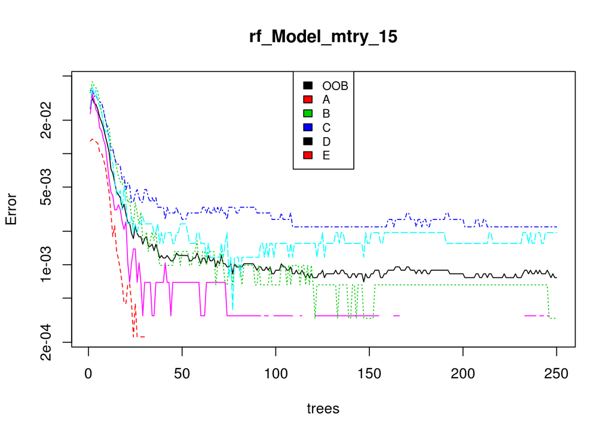

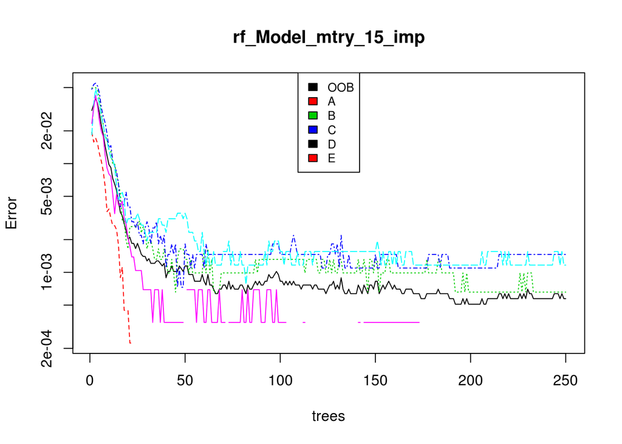

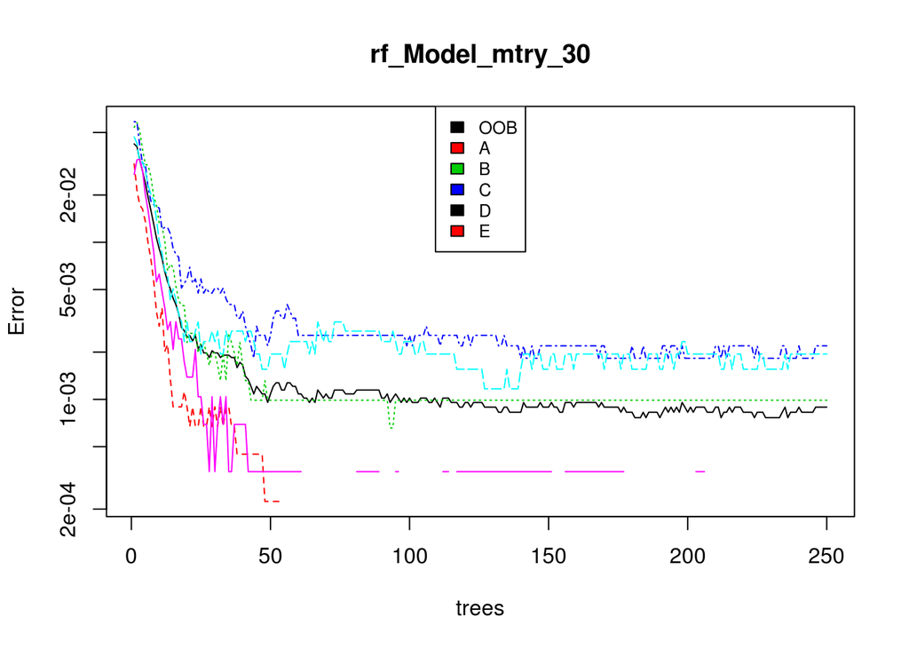

##### RCV Model Graph

The RCV model graphs the accuracy vs. the number of randomly selected predictors (mtry)

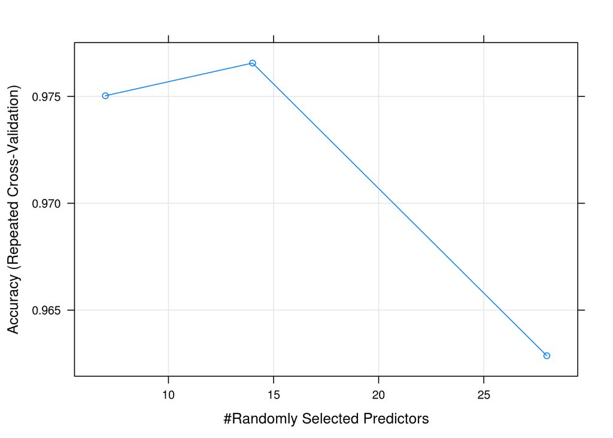

# Test Set Prediction

Finally we run the prediction with the model of highest accuracy against the test set:

```r
common <- intersect(names(clean_training_data), names(clean_testing_data))
for (p in common) {
  if (class(clean_training_data[[p]]) == "factor") {
    levels(clean_testing_data[[p]]) <- levels(clean_training_data[[p]])
  }
}

#print (setdiff(colnames(clean_testing_data), colnames(clean_training_data)))

predict(rf_Model_mtry_15, clean_testing_data)
```

```
##  1  2  3  4  5  6  7  8  9 10 11 12 13 14 15 16 17 18 19 20
##  B  A  B  A  A  E  D  B  A  A  B  C  B  A  E  E  A  B  B  B
## Levels: A B C D E
```

```r
#predict(rf_RCV_Model, clean_testing_data)
```